# Lesson23: R base graphics

Anna Williford

### What you should know at the end of this lesson

```
#Skills

Understand how to use R base graphics to make various plots
```

### Data visualization

There is no better quick way to detect patterns in data than to visualize your data.

Two types of data visualization:

- exploratory (quick data exploration - for yourself)
- explanatory (graph that makes a clear point for others)

### R graphics systems

There are 4 graphics systems in R:

- base
- grid
- lattice
- ggplot2

### Base graphics

This lesson is based on chapter by Ross Ihaka (Ross Ihaka and Robert Gentleman are the creators of R language)  
https://www.dropbox.com/s/lrbcnd2z2rzuzdn/BaseGraphics.pdf?dl=0

Default grapics in R:

- Very good for quick exploratory graphs
- Requires a lot of adjustments to get publication quality (explanatory) graphs

#### Basic example

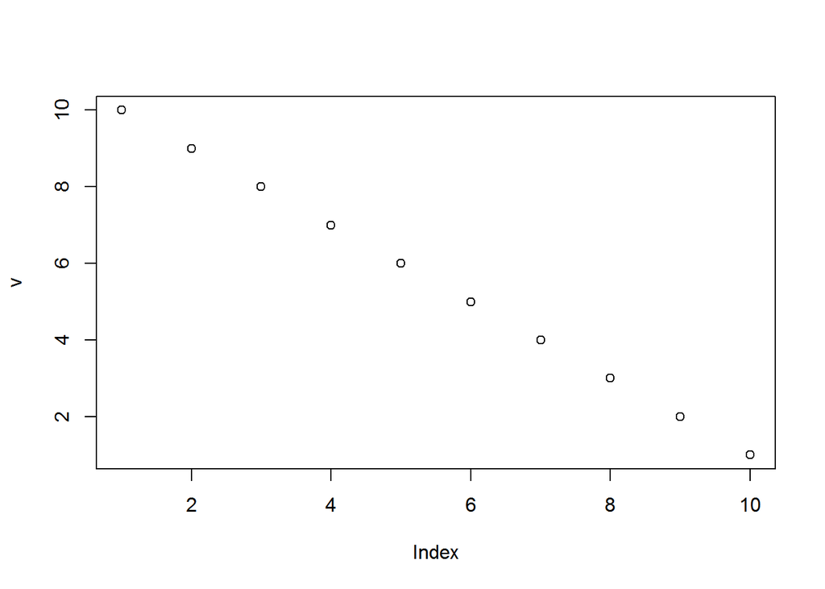

```r
#scatterplot
v<-10:1
plot(v)
```

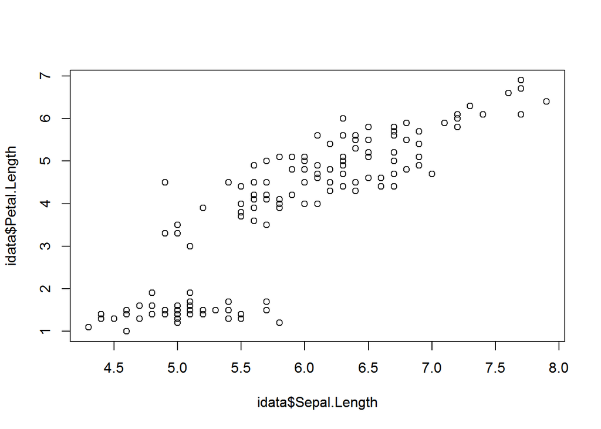

```r
#with iris data
idata<-iris
plot(idata$Sepal.Length,idata$Petal.Length)
```

Notice that a lot has happened here by default… Plot() is a high-level function that utilizes many low-level functions.

### How base R works

Painter’s model: start with empty canvas and add whatever you want step by step. There are many low-level functions with many arguments that control how individual parts of the graph are displayed. Let’s use them to recreate our iris-derived graph above that was made with high-level function plot()

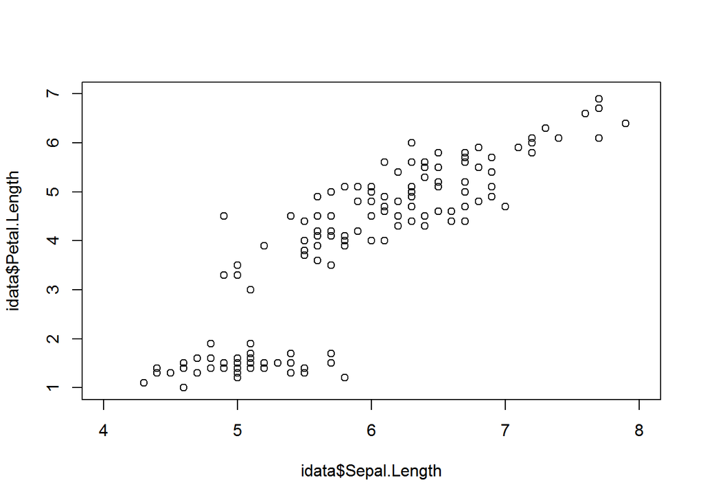

```r
#create new graphics frame
plot.new()

#set limits for x and y axes
plot.window(xlim=c(4,8), ylim=c(1,7))

#draw x axis
axis(1)

#draw y axis
axis(2)

#add points
points(idata$Sepal.Length,idata$Petal.Length)

#add annotation (x and y axes labels)
title(xlab="idata$Sepal.Length")
title(ylab="idata$Petal.Length")

#draw a box around the graph
box()
```

### Low-level functions

These functions can be used to add more detail to the plot created with high-level functions.

Base Graphics Cheatsheet:  
https://www.dropbox.com/s/3z3u392oaa2ujhh/BaseGraphicsCheatsheet.pdf?dl=0

```
###Add points
#points(x,y,pch,col,cex)
#points(x-coord, y-coord, plotting symbol, color, size)

points(seq(4,8,length=20),seq(7,1, length=20), pch=15, col="purple", cex=0.8)

#pch,col and cex can be vectors
points(seq(4,8,length=20),seq(7,1, length=20), pch=c(rep(16,10), rep(15,10)), col=c(rep("red",10),rep("green",10)), cex=c(rep(1.2,10), rep(0.5,10)))

###Add lines
#lines(x,y,lty,lwd,col)
lines(c(4,6,8), c(4,1,4), lty="dashed", lwd=2, col="blue")

###Add straight lines
#abline(a,b) #a=intercept, b=slope
abline(0,1)
abline(h=4)
abline(h=2:7,lty=4)
abline(v=mean(idata$Sepal.Length))

#fit a line
abline(lm(idata$Petal.Length~idata$Sepal.Length), col="purple", lwd=2.5)

###Add segment
#segments(x0, y0, x1, y1)
segments(5,2,5,5, lwd=2,col="black")

###Redraw our original plot to see what we add better
plot(idata$Sepal.Length,idata$Petal.Length)
#notice that when you run high-level function, new plot is created, and everything we have added is erased (starting new painting)

###Add arrows
arrows(4.5,4,4.8,4.5, length=0.1, angle=30, code=2, col="red")

###Add polygon
polygon(x,y)
Draw a polygon, when color is set with rgb function, 4th argument specifies transparency
polygon(c(4.8,4.8,5.3,5.3),c(2.5,5,5,2.5), col=rgb(1,0,0, 0.3))

###Add text to plot
text(x, y, labels)
text(6.2,2, "setosa", srt=45, font=3)

###Add legend
legend(7, 2, legend = c("setosa", "versicolor"), lty = c("solid", "dashed"), xjust = .5, yjust = .5, cex=0.7)

###Add axis
plot(1:10, axes=FALSE)
axis(2, at = c(1:10), col = "red", las=2, cex.axis=0.7)
#if you do not want any ticks on the x axis
box(col="red")

###Add title
title(main="My vector", col.main="red",ylab="Vector elements")
#title() cannot re-label, only add new labels...
#specify labels as aguments to high-level function
plot(1:10, axes=FALSE, ylab="vector elements", xlab=NA)
```

### Arguments to high-level function

Since low-level functions can only add to existing plot, but cannot replace what is already there, you want to specify how your main plot looks by providing arguments to high-level function

```
#For our iris example, decide the type of plot you want, what symbols to use, color and size. Also give x and y labels
plot(idata$Sepal.Length,idata$Petal.Length,pch=17,col="red", xlab="Sepal Length", ylab="Petal Length", cex=0.8 )

#Different symbol for every species?
idata$symbol<-c(rep(16,50), rep(17,50), rep(19,50))
#or
sym<-c(16,17,19)
idata$symbol<-rep(sym, each=50)
plot(idata$Sepal.Length,idata$Petal.Length,pch=idata$symbol,col="red", xlab="Sepal Length", ylab="Petal Length", cex=0.9)

#Could you set a symbol for a particular species?
idata[idata$Species=="setosa","symbol"]<-15
#or
idata$symbol[idata$Species=="setosa"]<-15

#Separating by species does not seem good enough
#Color by species
plot(idata$Sepal.Length,idata$Petal.Length,pch=idata$symbol,col=idata$Species, xlab="Sepal Length", ylab="Petal Length", cex=0.8 )
#why did this work?
```

### Working with color

We can make an additional column for color idata$color and assign any color we want. Colors can be specified by index, names, hexadecimals or RGB vector.

To use color by name:  
`color()`

Here is color code by index  
http://www.statmethods.net/advgraphs/parameters.html  
Here is how to convert between different color representations  
https://www.w3schools.com/colors/colors_converter.asp

```
#choosing color by index
idata$color<-c(rep(colors()[114],50), rep(colors()[116],50), rep(colors()[142],50))
plot(idata$Sepal.Length,idata$Petal.Length,pch=idata$symbol,col=idata$color, xlab="Sepal Length", ylab="Petal Length", cex=0.8 )
```

You can choose color from R palettes

```
example(rainbow)  #palettes in R

rCol<-rainbow(3)
idata$color<-rep(rCol, each=50)
plot(idata$Sepal.Length,idata$Petal.Length,pch=idata$symbol,col=idata$color, xlab="Sepal Length", ylab="Petal Length", cex=0.8 )
```

You can use RColorBrewer package  
http://colorbrewer2.org/#type=qualitative&scheme=Set3&n=3

```
install.packages("RColorBrewer")
library(RColorBrewer)
rCol <- brewer.pal(3,"Dark2")
idata$color<-rep(rCol, each=50)

plot(idata$Sepal.Length,idata$Petal.Length,pch=idata$symbol,col=idata$color, xlab="Sepal Length", ylab="Petal Length", cex=1)

#make a legend
legend("bottomright", legend = levels(iris$Species), col = rCol[1:3], pch = 16, cex=0.7)
```

Now save your plot:

```
pdf("Iris.pdf")
plot(idata$Sepal.Length,idata$Petal.Length,pch=idata$symbol,col=idata$color, xlab="Sepal Length", ylab="Petal Length", cex=1)
#Add title
title(main="Petal and Sepal Length in Iris Flowers",cex.main=1.1)
#make a legend
legend("bottomright", legend = levels(iris$Species), col = rCol[1:3], pch = 16, cex=1)
dev.off()

#you can specify the size and resolution when you start graphics device.
png(filename="myPlot", width=3.5, height=5, units="in", res=300)
```

### Other high-level functions

- boxplot()
- barplot()
- pie()
- hist()

Check with `?hist` for usage

### Graphical parameters

What else can be specified? Graphical parameters can be viewed and set with `par()` function. Some parameters can only be set with `par()` function. If you set parameters with `par()`, the change will apply to other plots; if you specify parameter value within plotting function, the change only takes place for that function call.

```
#view all
par()

#see what each parameter does
?par

#view individual parameter value
par("bg")

#xleft, xright, ybottom, and ytop of the plotting area
par("usr")

#specify multiple plots per window
par(mfrow=c(2,2))  #fill by row
par(mfcol=c(2,2))  #fill by col

#example
par(mfrow=c(1,2))
plot(1:10)
plot(10:1)
```

#### Practice

```
Add means for each species on our iris plot.
```

### Resources

- https://www.dropbox.com/s/lrbcnd2z2rzuzdn/BaseGraphics.pdf?dl=0
- http://www.statmethods.net/graphs/index.html